# Chapter 5

3. What happens if you try to use a continuous variable on the x axis in one layer, and a categorical variable in another layer? What happens if you do it in the opposite order?

First, we’ll try a continuous variable on the x-axis (`hwy`) in one layer, and a categorical variable (`class`) in another layer.

The code below returns the following error: `Error: Discrete value supplied to continuous scale`

`#ggplot(mpg) + geom_point(aes(hwy,cty)) + geom_point(aes(class,cty))`

Next, we’ll reverse the order of the two layers such that the categorical variable is plotted on the x-axis first and then the continuous variable. This order works.

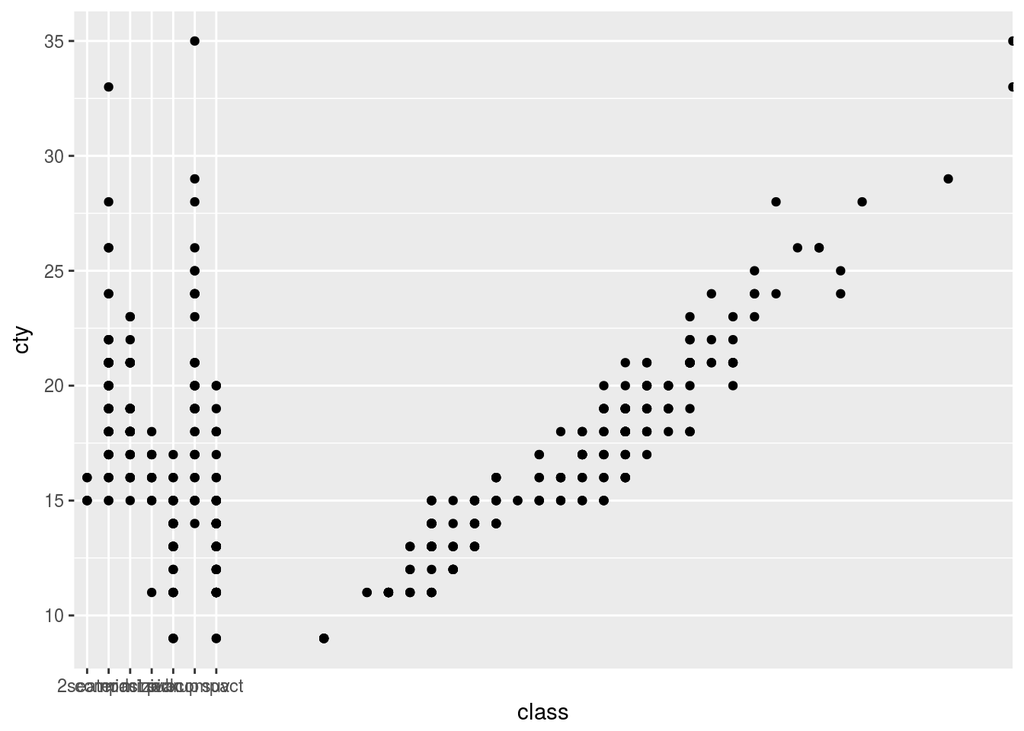

```r
ggplot(mpg) + geom_point(aes(class,cty)) + geom_point(aes(hwy,cty))
```

# 5.5.1 Exercises

1. Download and print out the ggplot2 cheatsheet from http://www.rstudio.com/resources/cheatsheets/ so you have a handy visual reference for all the geoms.

Done.

2. Look at the documentation for the graphical primitive geoms. Which aesthetics do they use? How can you summarize them in a compact form?

The graphical primitive geoms use the following aesthetics.

- `geom_point()`: x, y, alpha, color, fill, group, shape, size, stroke
- `geom_path()`: x, y, alpha, color, group, linetype, size
- `geom_ribbon()`: x, ymin, xmax, alpha, color, fill, group, linetype, size
- `geom_segment()`: x, y, xend, yend, alpha, color, group, linetype, size
- `geom_rect()`: xmin, xmax, ymin, ymax, alpha, color, fill, group, linetype, size
- `geom_polyon()`: x, y, alpha, color, fill, group, linetype, size
- `geom_text()`: x, y, label, alpha, angle, color, family, fontface, group, hjust, lineheight, size, vjust

Summarize them in a compact form: + position: x,y, ymin, ymax, xmin, xmax, angle, hjust, vjust + style: alpha, color, fill, shape, size, stroke, linetype, fontface, lineheight

- `geom_violin`
- `geom_point`
- `geom_hex` (Note that package `hexbin` is required.)
- `geom_jitter`
- `geom_line`
- `geom_path`
5. For each of the following problems, suggest a useful geom:
- Display how a variable has changed over time: `geom_line`
- Show the detailed distribution of a single variable: `geom_bar` (discrete), `geom_density` (continuous)
- Focus attention on the overall trend in a large dataset: `geom_smooth`
- Draw a map: `geom_map`
- Label outlying points: `geom_text`

# 5.6.2 Exercises

1. The code below creates a similar dataset to `stat_smooth()`. Use the appropriate geoms to mimic the default `geom_smooth()` display.

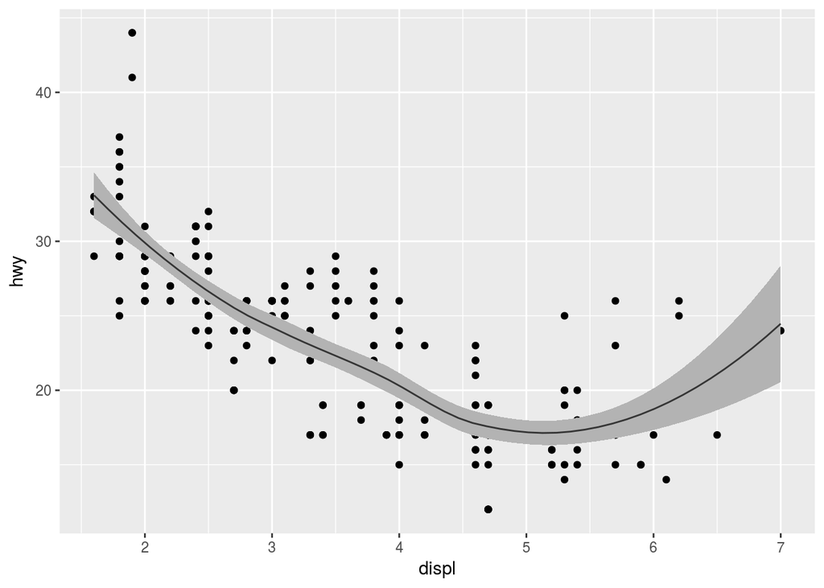

```r
mod <- loess(hwy ~ displ, data=mpg)
smoothed <- data.frame(displ= seq(1.6,7,length=50))
pred <- predict(mod, newdata=smoothed, se=TRUE)
smoothed$hwy <- pred$fit
smoothed$hwy_lwr <- pred$fit - 1.96 * pred$se.fit
smoothed$hwy_upr <- pred$fit + 1.96 * pred$se.fit

ggplot(mpg,aes(displ,hwy)) + geom_point()  + geom_ribbon(aes(x=displ,ymin=hwy_lwr,ymax=hwy_upr),data=smoothed,fill="grey70") + geom_line(aes(displ,hwy),data=smoothed,alpha=.7)
```

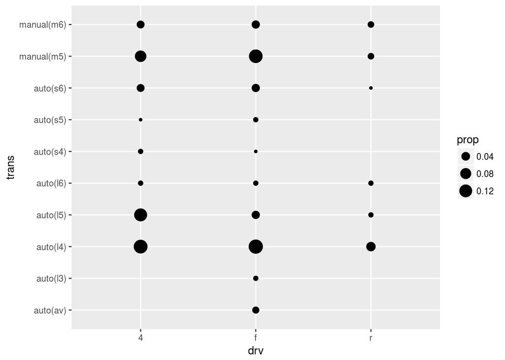

```r
ggplot(mpg,aes(drv,trans)) + geom_count(aes(size = ..prop.., group=1))
```

# 5.7.1 Exercises

1. When might you use `position_nudge()`? Read the documentation.

`position_nudge()` is especially useful with text to place it in a position where it is readable and not hiding data points.

2. Many position adjustments can only be used with a few geoms. For example, you can’t stack boxplots or error bars. Why not? What properties must a geom possess in order to be stackable? What properties must it possess to be dodgeable?
- You can’t stack boxplots or error bars. Why not?

Boxplots and error bars describe the variability of a single variable. Only one such description per variable makes sense.

- What properties must a geom possess in order to be stackable?

The geom can be used to describe different segments of the variable of interest. For example, a bar chart (bars can be stacked) can be used to describe a variable such as frequency of an income category using stacked bars to differentiate between male and female.

Similar to stackable geoms, dodgeable geoms must have multiple values per variable. We could use dodging in the example above to compare salaries of males to salaries of females to place the bars side by side. This would be more useful to compare the heights of the bars.

3. Why might you use `geom_jitter()` instead of `geom_count()`? What are the advantages and disadvantages of each technique?
- `geom_jitter()`: Might use this for smaller datasets. Con: For large datasets, jitter may not be enough to see all points.
- `geom_count()`: Might use this if the data size is larger. Size of point indicates count or proportion of datapoints at that location. Con?
4. When might you use a stacked area plot? What are the advantages and disadvantages compared to a line plot?
- stacked area plot: Use when you are interested in trends of combinations of variables. The $n^{th}$ area shows the trend of the combination of the first $n$ variables.
- line plot: Use when you are interested in comparing the trend of each variable separately (and in contrast to one another).